**Dynamic Systems:**  
**Linear Transform**

By Prof. Seungchul Lee  
http://iai.postech.ac.kr/  
Industrial AI Lab at POSTECH

Table of Contents

# 1. Linear Transforms: Fourier and Laplace Transforms

## 1.1. Inner Product

- For real valued vector

$$\vec{x}\cdot\vec{y} = \langle \vec{x}, \vec{y} \rangle = x^T y =\sum x_iy_i \quad \text{: similarity index}$$

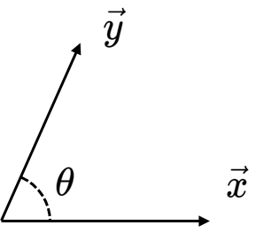

- Orthogonal

$$ x^Ty=0 \implies x \perp y $$

- Suppose $\hat{b}_i$ orthogonal basis
  - Any $\vec{x}$ can be represented (decomposed) with linear combinations of $\hat{b}_i$
    $$\vec{x} = c_1\hat{b}_1 + c_2\hat{b}_2 + \cdots + c_n\hat{b}_n$$
  - Question: How to find $c_i$?
    $$ \begin{align*} \langle \vec{x}, \hat{b}_i \rangle &= c_1\langle \hat{b}_1, \hat{b}_i \rangle + \cdots + c_i\langle \hat{b}_i, \hat{b}_i \rangle + \cdots + c_n \langle \hat{b}_n, \hat{b}_i \rangle\\ \\ \therefore c_i & = {\langle x, \hat{b}_i \rangle \over \langle \hat{b}_i, \hat{b}_i \rangle} \end{align*} $$
  - Meaning: $c_i$ indicates how much $\hat{b}_i$ information contains in $\vec{x}$

## 1.2. Hermitian Transpose

- For complex values

$$\langle \vec{x}, \vec{y} \rangle = y^Hx \quad \text{where } y^H \text{ is complex conjugate transpose of } y $$

- Want to know how much $e^{j\omega t}$ component is contained in $x(t)$.

$$\begin{align*} \langle x, e^{j\omega t} \rangle &= \int \left(e^{j \omega t} \right)^Hx(t) \,dt \\ &= \int x(t)e^{-j \omega t} \, dt \\ & = X(j\omega) \end{align*} $$

## 1.3. Fourier Transform

$$X(j\omega) = \int x(t)e^{-j \omega t} \, dt $$

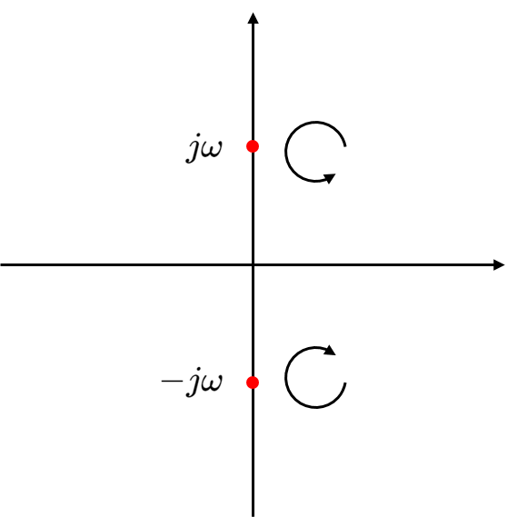

## 1.4. Laplace Transform

- Want to know how much $e^{-\sigma+j\omega t} = e^{-\sigma} \, e^{j \omega t}$ component is contained in $x(t)$
- Let $s = \sigma+j \omega t$

$$ \begin{align*} \left\langle x, e^{-\sigma + j\omega t} \right\rangle &= \int \left(e^{-\sigma+j \omega t}\right)^H x(t) \, dt \\ & = \int x(t)e^{-\sigma-j\omega t}dt \\ & = \int x(t)e^{-st}dt\\ & = X(s) \end{align*} $$

- Laplace Transform

$$X(s) = \int x(t)e^{-st}dt$$

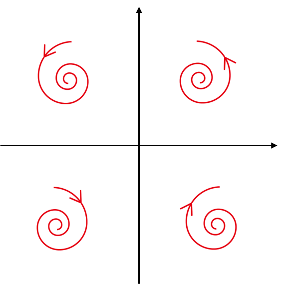

# 2. Laplace Transform

- Eigenfunction Property of $e^{st}$
- The system output is given by

$$ \begin{align*} y(t) &= H\{x(t)\} \\ &= h(t) * x(t) \\ &= \int^\infty_{-\infty} h(\tau)x(t - \tau)d\tau \end{align*} $$

- Let $e^{st}$ be a complex exponential with complex frequency $s = \sigma + j\omega$
- When $x(t) = e^{st}$

$$ \begin{align*} y(t) &= \int^\infty_{-\infty} h(\tau) e^{s(t - \tau)}d\tau \\ &= e^{st} \int^\infty_{-\infty} h(\tau) e^{-s\tau}d\tau \end{align*} $$

- We define the transfer function

$$ H(s) = \int^\infty_{-\infty} h(\tau) e^{-s\tau}d\tau$$

- We may write

$$y(t) = H\{e^{st}\} = H(s)e^{st}$$

- If the output signal is a scalar multiple of the input signal, we refer to the signal as an eigenfunction and the multiplier as the eigenvalue

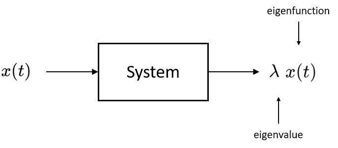

- Complex exponentials are eigenfunctions of LTI systems.
- If $x(t) = e^{st}$ and $h(t)$ is the impulse response then

$$ \begin{align*} y(t) &= (h*x)(t) = \int^\infty_{-\infty} h(\tau)e^{s(t-\tau)}d\tau = e^{st}\int^\infty_{-\infty}h(\tau)e^{-s\tau}d\tau \\ &= H(s)e^{st} \end{align*} $$

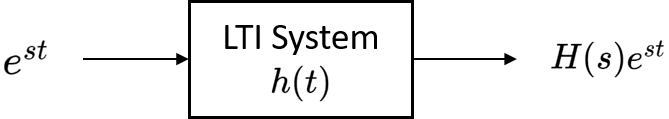

- The eigenvalue associated with $e^{st}$ is $H(s)$.

## 2.2. Laplace Transform: Definition

- Laplace transform maps a function of time $t$ to a function of $s$ (complex frequency)
  - The Laplace transform is similar to the Fourier transform.

$$X(s) = \int^\infty_{-\infty}x(t) e^{-st}dt$$

**Example**

- Find the laplace transform of $x(t)$ (where $u(t)$ is unit step function),

$$x(t) = e^{-t}u(t) = \begin{cases} e^{-t} & \text{if } t > 0 \\ 0 & \text{otherwise} \end{cases} $$

$$ \begin{align*} X(s) &= \int^\infty_{-\infty}x(t) e^{-st}dt = \int^\infty_0 e^{-t}e^{-st}dt = \int^\infty_0 e^{-(s+1)t}dt \\ &= {e^{-(s+1)t} \over -(s+1)}\biggr\rvert^\infty_0 = {1 \over s+1} \end{align*} $$

- Provided $\text{Re}(s+1) > 0$ which implies that

$$\underbrace{\text{Re}(s) > -1}_{\text{Regions of Convergence (ROC)}}$$

**Example**

$$ \begin{align*} x(t) &= 3e^{-2t}u(t)-2e^{-t}u(t)\\\\ X(s) &= \underbrace{3 \over s+2}_{\text{Re}(s) > -2} - \underbrace{2 \over s+1}_{\text{Re}(s) > -1} = {3(s+1) - 2(s+2) \over (s+2)(s+1)} = \underbrace{s-1 \over s^2 + 3s + 2}_{\text{Re}(s)>-1} \end{align*} $$

**Example**

- Laplace transform of the impulse function

$$ \begin{align*} x(t) &= \delta(t)\\ \\ X(s) &= \int^\infty_{-\infty} \delta(t)e^{-st}dt = \int^\infty_{-\infty} \delta(t)e^{-st}\biggr\rvert_{t = 0}dt \\ &= \int^\infty_{-\infty} \delta(t) \cdot 1 dt = 1 \end{align*} $$

- Sifting property
  - Multiplying $f(t)$ by $\delta(t)$ and integrating over $t$ sifts out $f(0)$

## 2.3. Unit Impulse Signal

- The unit-impulse signal acts as a pulse with unit area but zero width

$$\delta(t) = \lim_{\epsilon\rightarrow0}p_\epsilon(t)$$

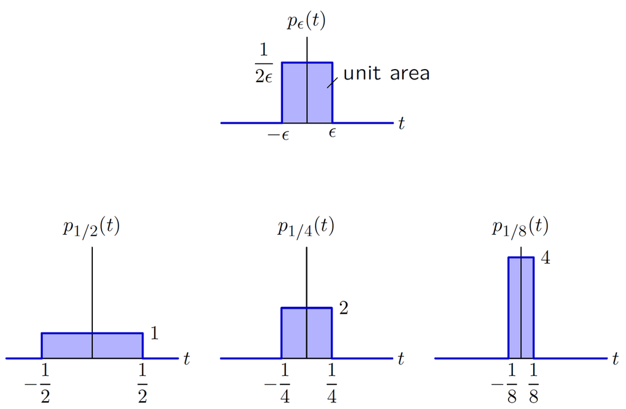

- The unit-impulse function is represented by an arrow with the number 1, which represents its area

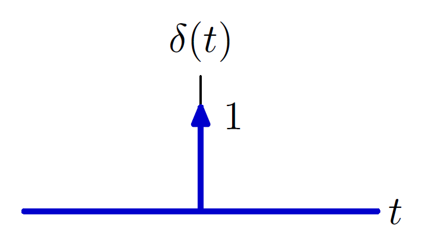

- It has two seemingly contradictory properties :
  - It is nonzero only at $t = 0$ and
  - Its definite integral ($-\infty$, $\infty$) is 1
- Laplace transform of unit-impulse function

$$ D(s) = \int^{\infty}_{-\infty}\delta(t)e^{-st}dt = e^{-s0} = 1 $$

## 2.4. Unit Step Signal

- The indefinite integral of the unit-impulse is the unit-step

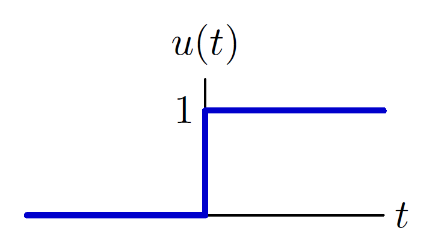

$$u(t) = \int^t_{-\infty}\delta(\tau)d\tau = \begin{cases} 1 & t \geq 0 \\ 0 & \text{otherwise} \end{cases} $$

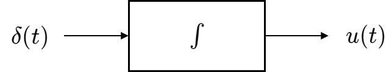

- Laplace transform of unit-step function

$$ U(s) = \int^{\infty}_{-\infty}u(t)e^{-st}dt = \int^{\infty}_{0}1\cdot e^{-st}dt = {e^{-st} \over -s}\biggr\rvert^\infty_0 = {1 \over s}, \qquad \text{ Re}\{s\}>0 $$